# Dimensionality Reduction with PCA and Visualization with t-SNE

### **Lab Tasks & Exercises**

Now, apply what you've learned. The following code cell contains three tasks to help you explore the concepts of PCA and t-SNE further.

```
Components for 80% variance: 21
```

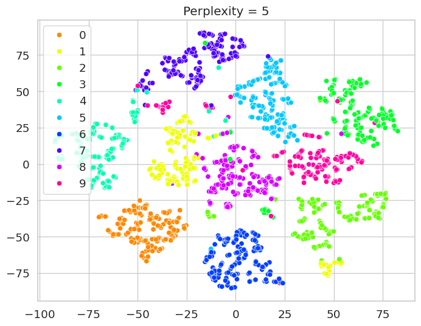

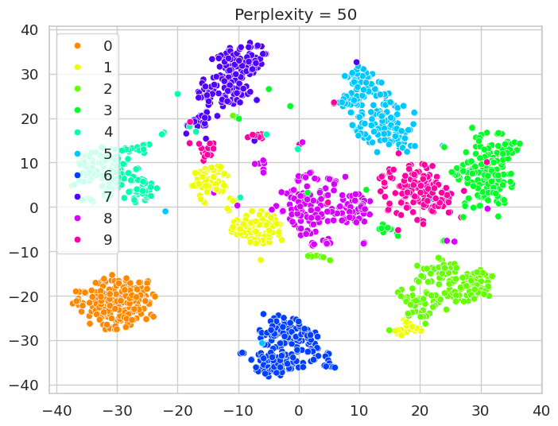

```
Original Data -> Accuracy: 0.9722, Time: 0.7514s
PCA-Reduced Data -> Accuracy: 0.9611, Time: 0.5276s
```

```python
# # --- TASK 1: PCA Variance Threshold ---
# # Re-run the PCA analysis to find the number of components needed to capture 80% of the variance.
# # How many components are needed? How does this compare to the 95% threshold?

# # YOUR CODE HERE
# pca_80 = PCA(n_components=0.80)
# X_pca_80 = pca_80.fit_transform(X_scaled)
# print(f"Components for 80% variance: {X_pca_80.shape[1]}")


# # --- TASK 2: t-SNE Perplexity ---
# # Re-run the t-SNE visualization twice, first with a very low perplexity (e.g., 5) and then with a
# # very high one (e.g., 50 or 100). Plot the results.
# # How does the visualization change? What does this tell you about the role of perplexity?

# # YOUR CODE HERE for perplexity=5
# tsne_5 = TSNE(n_components=2, perplexity=5, random_state=42)
# X_tsne_5 = tsne_5.fit_transform(X_scaled)
# plt.figure(figsize=(8,6))
# sns.scatterplot(x=X_tsne_5[:,0], y=X_tsne_5[:,1], hue=y, palette=sns.color_palette("hsv", 10)).set_title('Perplexity = 5')
# plt.show()

# # YOUR CODE HERE for perplexity=50
# tsne_50 = TSNE(n_components=2, perplexity=50, random_state=42)
# X_tsne_50 = tsne_50.fit_transform(X_scaled)
# plt.figure(figsize=(8,6))
# sns.scatterplot(x=X_tsne_50[:,0], y=X_tsne_50[:,1], hue=y, palette=sns.color_palette("hsv", 10)).set_title('Perplexity = 50')
# plt.show()


# # --- TASK 3: PCA for Model Performance ---
# # PCA is not just for visualization; it's a powerful preprocessing step.
# # 1. Train a Logistic Regression classifier on the ORIGINAL scaled data (X_scaled, y).
# # 2. Train another Logistic Regression classifier on the PCA-REDUCED data (X_pca, y).
# # 3. Compare their accuracy and training time. What do you observe?

# # Split the data
# X_train_orig, X_test_orig, y_train, y_test = train_test_split(X_scaled, y, test_size=0.2, random_state=42)
# X_train_pca, X_test_pca, _, _ = train_test_split(X_pca, y, test_size=0.2, random_state=42)

# # YOUR CODE HERE for the original data
# log_reg_orig = LogisticRegression(max_iter=1000, random_state=42)
# start = time.time()
# log_reg_orig.fit(X_train_orig, y_train)
# end = time.time()
# y_pred_orig = log_reg_orig.predict(X_test_orig)
# acc_orig = accuracy_score(y_test, y_pred_orig)
# print(f"Original Data -> Accuracy: {acc_orig:.4f}, Time: {end-start:.4f}s")

# # YOUR CODE HERE for the PCA-reduced data
# log_reg_pca = LogisticRegression(max_iter=1000, random_state=42)
# start = time.time()
# log_reg_pca.fit(X_train_pca, y_train)
# end = time.time()
# y_pred_pca = log_reg_pca.predict(X_test_pca)
# acc_pca = accuracy_score(y_test, y_pred_pca)
# print(f"PCA-Reduced Data -> Accuracy: {acc_pca:.4f}, Time: {end-start:.4f}s")
```

### **Part 7: Advanced Topics & Discussion**

- **Linear vs. Non-linear Methods:** PCA is a linear method, meaning it can only capture linear relationships in the data. t-SNE is a non-linear (or manifold learning) method, allowing it to uncover complex, curved structures. For highly non-linear data, other techniques like **UMAP (Uniform Manifold Approximation and Projection)**, which is often faster and better at preserving global structure than t-SNE, or **Kernel PCA** are powerful alternatives.
- **PCA for Preprocessing vs. t-SNE for Visualization:** This is the most critical takeaway. **PCA is an excellent preprocessing step** to reduce features before feeding them into a supervised model, as it can reduce noise, prevent overfitting, and speed up training (as seen in Task 3). **t-SNE should *not* be used for this**; it is almost exclusively a tool for **exploratory data analysis and visualization**.
- **Interpreting PCA Components:** While PCA components are mathematically abstract, you can inspect the `components_` attribute of the fitted PCA object. Each component is a vector where the values correspond to the original features. A large absolute value means that the original feature contributes strongly to that component, allowing for some level of interpretation.
- **Limitations of t-SNE:** While powerful for visualization, t-SNE results must be interpreted with caution:
  - **Cluster sizes are not meaningful:** A cluster that looks larger on a t-SNE plot does not necessarily contain more points or have more variance.
  - **Distances between clusters are not meaningful:** You cannot conclude that two clusters that are far apart are "more different" than two clusters that are close together. t-SNE preserves local neighborhoods, not global distances.
  - **It's a visualization tool, not a clustering algorithm:** While it reveals clusters, you should use formal algorithms like K-Means or DBSCAN to assign points to clusters.

Prepared By

**Md. Atikuzzaman**  
Lecturer  
Department of Computer Science and Engineering  
Green University of Bangladesh  
Email: atik@cse.green.edu.bd